# Trabajo_Grupal

Melany Chaves, Fabricio Gomez, Rafael Chaves

2023-04-14

# *En que consiste ggplot2*

Es un paquete de R dedicado a la visualización de data, nos permite crear gráficos de alta calidad. Forma parte del conjunto de librerías llamado tidyverse *ggplot2* se caracteriza por su facilidad de uso y la capacidad de crear gráficos complejos con relativamente pocas líneas de código.

## *Crear un gráfico con ggplot2*

Se usan estos elementos:

1. Un data frame que contiene los datos que se quieren visualizar.
2. Los aesthetics, es decir, una lista de relaciones entre las variables del fichero de datos y determinados aspectos del gráfico (como por ejemplo coordenadas, formas o colores).
3. Los geoms, que especifican los elementos geométricos (puntos, líneas, círculos, etc) que se van a representar.

El comando ggplot se usa para generar el sistema de coordenadas (por defecto, rectangulares) y posteriormente vamos añadiendo los geoms con sus correspondientes aesthetics. En principio los aesthetics se pueden asignar individualmente para cada geom.

**Ejemplo:**

ggplot(data = ‘nombre del fichero de datos’) + geom_nombre1(aes(aesthetics1=var1, aesthetics2=var2, …)) + geom_nombre2(…)

Empezamos a construir la información con geoms:

**Importante: los datos a representar siempre tienen que formar parte de un data frame**

Podemos especificar sí las columnas deben ser de algún color, tamaño, etc con el argumento aesthetics **(aes)**

### *Tipos de geom*

Existen diferentes tipos de gráficos:

1.geom_point: puntos 2.geom_lines: lineas 3.geom_bar: barras 4.geom_histogram: histogramas

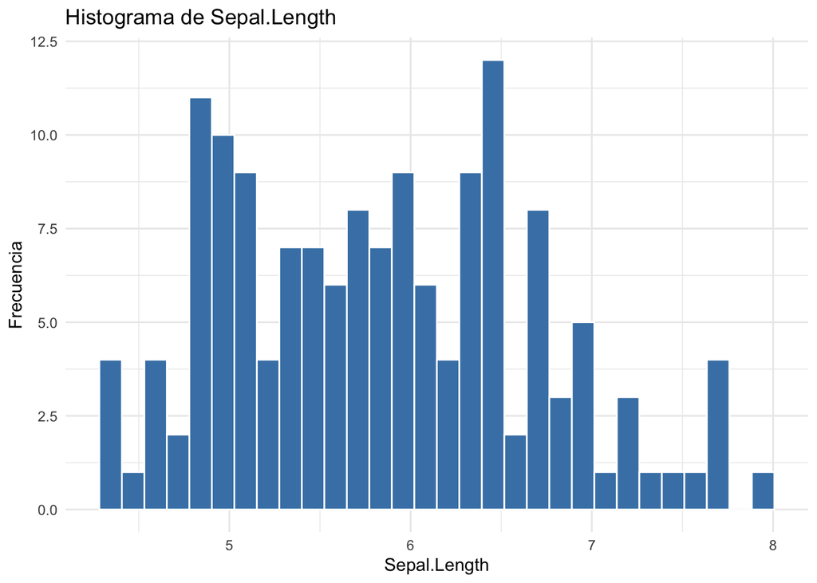

```r
library(ggplot2)
data(iris)

# Graficar histograma de cada variable numérica
ggplot(iris, aes(x = Sepal.Length)) +
  geom_histogram(fill = "steelblue", color = "white") +
  labs(title = "Histograma de Sepal.Length",
       x = "Sepal.Length", y = "Frecuencia") +
  theme_minimal()
```

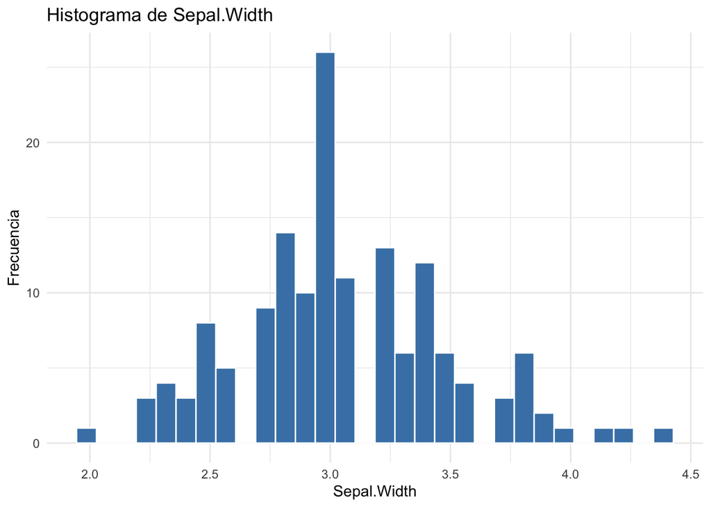

```r
ggplot(iris, aes(x = Sepal.Width)) +
  geom_histogram(fill = "steelblue", color = "white") +
  labs(title = "Histograma de Sepal.Width",
       x = "Sepal.Width", y = "Frecuencia") +
  theme_minimal()
```

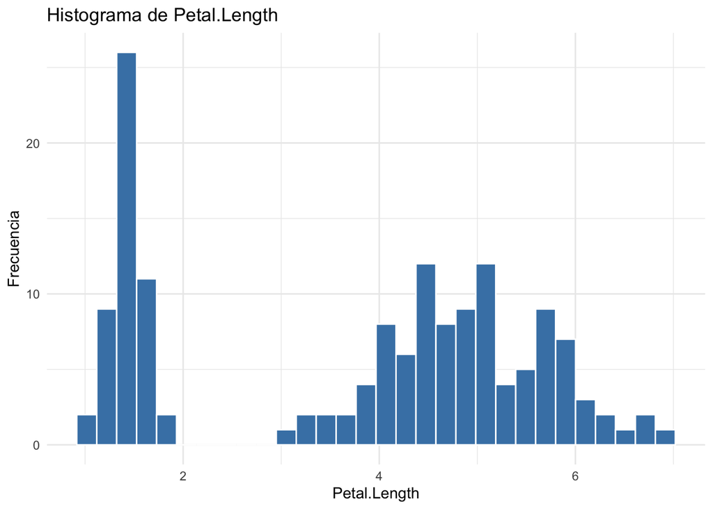

```r
ggplot(iris, aes(x = Petal.Length)) +
  geom_histogram(fill = "steelblue", color = "white") +
  labs(title = "Histograma de Petal.Length",
       x = "Petal.Length", y = "Frecuencia") +
  theme_minimal()
```

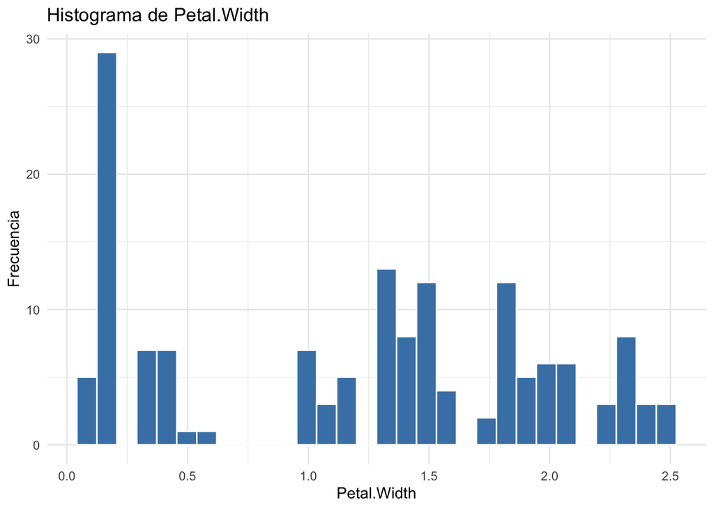

```r
ggplot(iris, aes(x = Petal.Width)) +
  geom_histogram(fill = "steelblue", color = "white") +
  labs(title = "Histograma de Petal.Width",
       x = "Petal.Width", y = "Frecuencia") +
  theme_minimal()
```